## 1. Code for reading in the dataset and/or processing the data

```r
library(data.table)
activity_dt<-data.table(read.csv("activity.csv"))
activity_dt$date<-as.POSIXct(activity_dt$date, "%Y-%m-%d")
activity_dt$interval<-as.factor(activity_dt$interval)
```

## 2.Histogram of the total number of steps taken each day

Calculation the total number of steps taken per day

```r
steps_taken_per_day<-tapply(activity_dt$steps,activity_dt$date,sum, na.rm=TRUE)
```

Histogram of the total number of steps taken each day

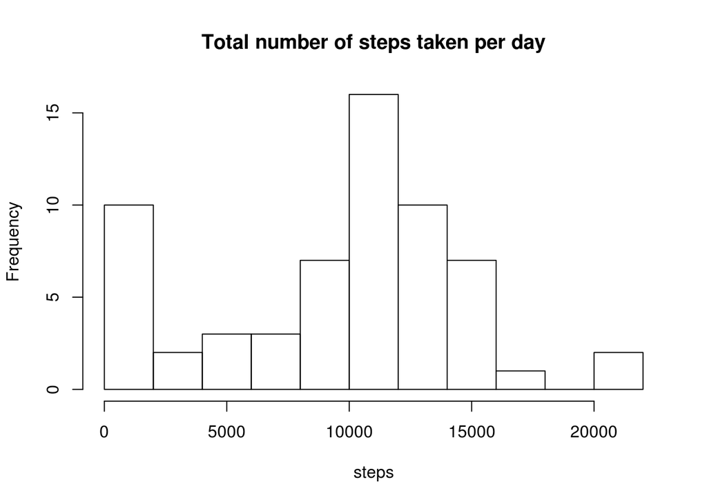

```r
hist(steps_taken_per_day, main="Total number of steps taken per day",
     xlab="steps",breaks=10)
```

## 3. Mean and median number of steps taken each day

```r
mean(steps_taken_per_day)
```

```
## [1] 9354.23
```

```r
median(steps_taken_per_day)
```

```
## [1] 10395
```

## 4. Time series plot of the average number of steps taken

Time series plot (i.e. type = “l”) of the 5-minute interval (x-axis) and the average number of steps taken, averaged across all days (y-axis)

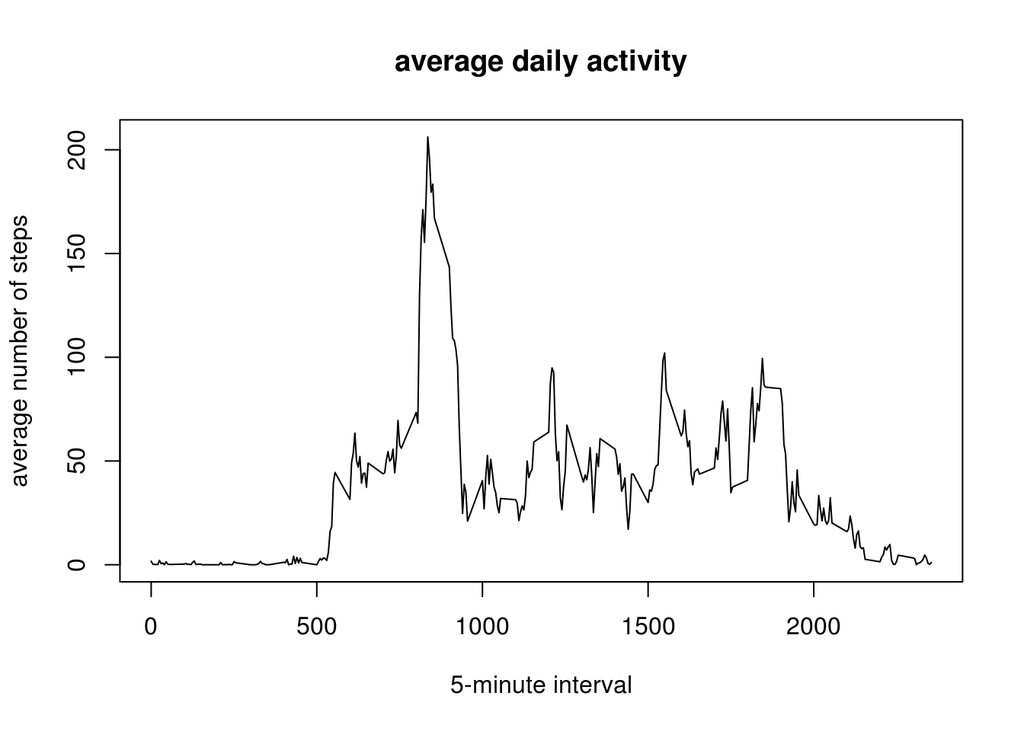

```r
avg_steps_per_interval<-tapply(activity_dt$steps,activity_dt$interval,mean, na.rm=TRUE)
plot(names(avg_steps_per_interval),avg_steps_per_interval,xlab="5-minute interval", ylab="average number of steps", main="average daily activity",type = "l")
```

## 5. The 5-minute interval that, on average, contains the maximum number of steps

```r
names(avg_steps_per_interval)[which.max(avg_steps_per_interval)]
```

```
## [1] "835"
```

## 6. Code to describe and show a strategy for imputing missing data

The total number of missing values in the dataset

```r
nrow(activity_dt[is.na(activity_dt$steps),])
```

```
## [1] 2304
```

I use the mean for that 5-minute interval to Imputing missing values.

```r
activity_dt[,interval_mean:=mean(steps,na.rm=TRUE), by=interval]
NA_row<-is.na(activity_dt$steps)
activity_dt$new_steps<-activity_dt$steps
activity_dt$new_steps[NA_row]<-activity_dt$interval_mean[NA_row]
```

Create a new dataset that is equal to the original dataset but with the missing data filled in

```r
activity_dt_new<-activity_dt[,c("date","interval","new_steps"), with=FALSE]
```

## 7. Histogram of the total number of steps taken each day after missing values are imputed

Two histograms of the total number of steps taken each day and Calculate.  
Befor and after.

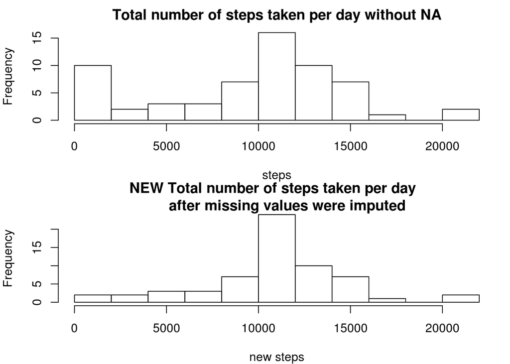

```r
steps_taken_per_day_new<-tapply(activity_dt_new$new_steps,activity_dt_new$date,
                                sum, na.rm=TRUE)
par(mfrow=c(2,1),mar=c(4,4,2,1))
hist(steps_taken_per_day, main="Total number of steps taken per day without NA",
     xlab="steps",breaks=10)
hist(steps_taken_per_day_new, main="NEW Total number of steps taken per day
     after missing values were imputed", xlab="new steps",breaks=10)
```

Mean and median total number of steps taken per day

```r
mean(steps_taken_per_day_new)
```

```
## [1] 10766.19
```

```r
median(steps_taken_per_day_new)
```

```
## [1] 10766.19
```

Values differ from the estimates from the first part of the assignment

## 8. Panel plot comparing the average number of steps taken per 5-minute interval across weekdays and weekends

```r
activity_dt_new[,day_name:=weekdays(date,TRUE)]
day_name=c("Mon","Tue","Wed","Thu","Fri","Sat","Sun")
week_part=c(rep("weekday",5),rep("weekend",2))
week_table<-data.table(day_name,week_part)
setkey(activity_dt_new,day_name)
setkey(week_table,day_name)
activity_dt_new<-merge(x = activity_dt_new, y = week_table, by = "day_name", all.x = TRUE)
activity_dt_new$week_part<-as.factor(activity_dt_new$week_part)
```

The panel plot containing a time series plot of the 5-minute interval (x-axis) and the average number of steps taken, averaged across all weekday days or weekend days (y-axis)

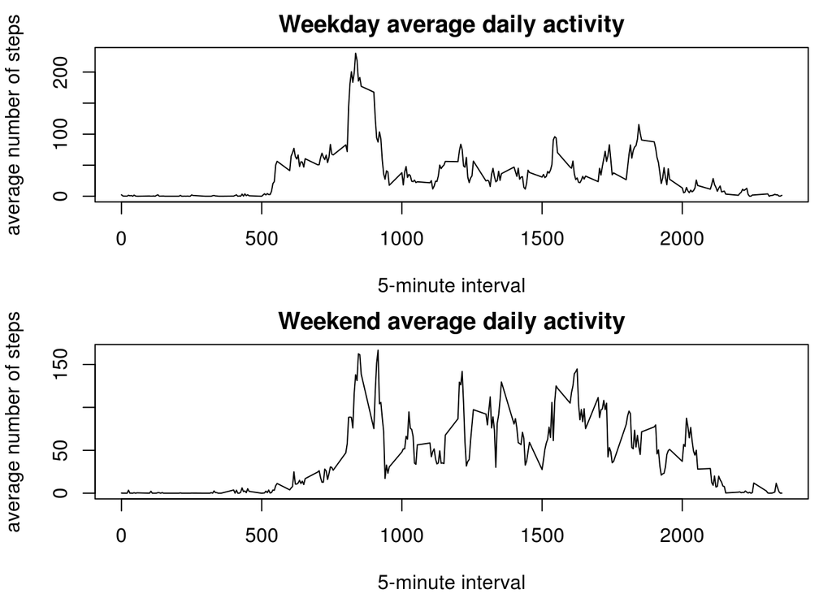

```r
weekday<-activity_dt_new[activity_dt_new$week_part=="weekday"]
weekend<-activity_dt_new[activity_dt_new$week_part=="weekend"]

avg_steps_per_interval_weekday=tapply(weekday$new_steps,weekday$interval,
                                      mean, na.rm=TRUE)
avg_steps_per_interval_weekend=tapply(weekend$new_steps,weekend$interval,
                                      mean, na.rm=TRUE)

par(mfrow=c(2,1),mar=c(4,4,2,1))
plot(names(avg_steps_per_interval_weekday),avg_steps_per_interval_weekday,
     xlab="5-minute interval", ylab="average number of steps",
     main="Weekday average daily activity",type = "l")
plot(names(avg_steps_per_interval_weekday),avg_steps_per_interval_weekend,
     xlab="5-minute interval", ylab="average number of steps",
     main="Weekend average daily activity",type = "l")
```